# My SpotifyR report

Author

Joy Lee

# Let’s talk about Adele

## Who is Adele?

She’s just great.

### Her quote

> *“There’s a fire starting in my heart”*  
> ― **Adele**

### Her albums

- 19 (released in 2008)
- 21 (2011)
- 25 (2015)
- 30 (2021)

## My picks

### My favorite album

[figure not shown]

### My favorite song

[Hello (2015, YouTube link)](https://youtu.be/YQHsXMglC9A?si=UFSjtoEA2IsdiC_G)

[video not shown]

### My favorite lyrics

> Hello, it’s me  
> I was wondering if after all these years you’d like to meet  
> To go over everything  
> They say that time’s supposed to heal ya, but I ain’t done much healing

> …

## Data analysis

### Data source

I extracted the data using the `spotifyr` package, and stored it in the data folder.

### Import data

```r
# These are packages I need for the analysis
library(ggplot2)
library(dplyr)

# Import data into df
df <- read.csv("data/Adele.csv")
```

### Take a glance of the data frame

```r
# Slice 5 random records in the dataframe
df |> dplyr::slice_sample(n=5) |> knitr::kable(digits = 2)
```

| artist_name | track_name | track_number | album_name | album_release_year | album_release_date | valence | energy | danceability | loudness | tempo | speechiness | instrumentalness | liveness | key_name | mode_name | key_mode | duration_ms |
| --- | --- | --- | --- | --- | --- | --- | --- | --- | --- | --- | --- | --- | --- | --- | --- | --- | --- |
| Adele | Best For Last | 2 | 19 | 2008 | 2008-11-17 | 0.62 | 0.32 | 0.56 | -10.92 | 87.27 | 0.33 | 0 | 0.11 | E | minor | E minor | 258506 |
| Adele | Can I Get It | 6 | 30 | 2021 | 2021-11-19 | 0.54 | 0.68 | 0.70 | -6.12 | 97.98 | 0.04 | 0 | 0.18 | A | minor | A minor | 210384 |
| Adele | I’ll Be Waiting | 8 | 21 | 2011 | 2011-01-24 | 0.75 | 0.85 | 0.55 | -2.68 | 160.06 | 0.04 | 0 | 0.11 | D | major | D major | 241351 |
| Adele | Don’t You Remember | 4 | 21 | 2011 | 2011-01-24 | 0.23 | 0.40 | 0.64 | -5.71 | 115.03 | 0.03 | 0 | 0.09 | D# | major | D# major | 243200 |
| Adele | When We Were Young | 4 | 25 | 2015 | 2015-11-20 | 0.26 | 0.60 | 0.38 | -5.94 | 144.36 | 0.05 | 0 | 0.10 | D# | major | D# major | 290900 |

## Data preparation

Since there are some duplicated tracks, I’ve cleaned them. Also, I removed the tracks in live versions of the same songs.

```r
# Remove records with the same track names
df <- df |> distinct(track_name, .keep_all = TRUE)
# Filter out track names that include "Live at" or "Live Acoustic"
df <- df |> filter(!grepl("Live at|Live Acoustic", track_name))
# Change the data type of album_name from numeric into character
df$album_name <- as.character(df$album_name)
```

### Album analysis (valence and energy)

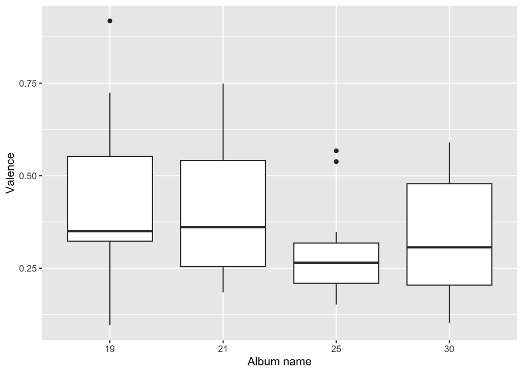

```r
# Change album_name from character to factor before plotting
df$album_name <- as.factor(df$album_name)
# Plot a boxplot
ggplot(df, aes(x=album_name, y=valence))+
  geom_boxplot()+
  labs(x="Album name", y="Valence")
```

For valence level, the album 25 has the lowest medium. Was she sad when writing the song for the album 25?

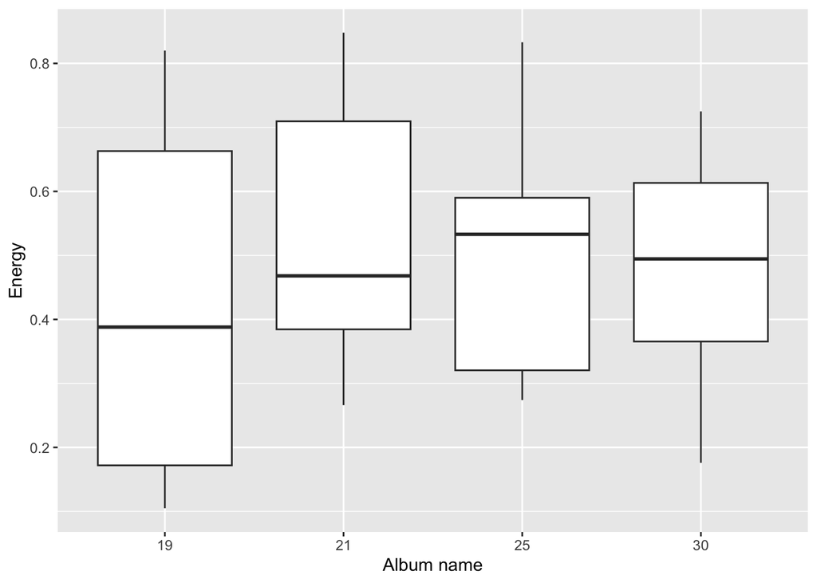

```r
ggplot(df, aes(x=album_name, y=energy))+
  geom_boxplot()+
  labs(x="Album name", y="Energy")
```

But when looking at the energy level, she’s not losing her energy in the album 25!

## Adele’s most positive song

Let’s look at the 3 most positive songs of her.

```r
df |> slice_max(valence, n=3) |> dplyr::select(track_name, album_name, album_release_year, valence) |> knitr::kable(digits = 2)
```

| track_name | album_name | album_release_year | valence |
| --- | --- | --- | --- |
| Right As Rain | 19 | 2008 | 0.92 |
| I’ll Be Waiting | 21 | 2011 | 0.75 |
| He Won’t Go | 21 | 2011 | 0.73 |

Now look at the 3 most energetic songs.

```r
df |> slice_max(energy, n=3) |> dplyr::select(track_name, album_name, album_release_year, energy) |> knitr::kable(digits = 2)
```

| track_name | album_name | album_release_year | energy |
| --- | --- | --- | --- |
| I’ll Be Waiting | 21 | 2011 | 0.85 |
| Water Under the Bridge | 25 | 2015 | 0.83 |
| Cold Shoulder | 19 | 2008 | 0.82 |

[video not shown]